# Delineating Super Region

Martin Durocher

2020-04-07

## Introduction

For a hydrometric station with a few years of observations, the uncertainty derived from the estimation of the flood quantiles can be substantial. In such a situation, pooled frequency analysis may reduce this variability by transferring information from nearby sites to a target site. FloodNet recommends forming pooling groups according to a notion of distance based on a measure of similarity that accounts for the regularity and timing of annual maximum discharges. There is a vast diversity of flood regimes among Canadian rivers. Super regions represent hydrologically similar groups of stations that serve as an initial population for performing pooling analysis. The file `gauged_sites.csv` suggests such four classes of super regions and this document explained the methodology behind them.

## Methodology

We consider two spaces, the descriptor and the geographical space. The descriptor space has for coordinates the drainage area (AREA) and mean annual precipitation (MAP), while the geographical space has longitude and latitude for coordinates. In Canada, AREA and MAP are surrogates for climate and scale. See Mostofi Zadeh and Burn (2019) for more details. The graphic below shows the 1114 gauged stations of interest inside these two spaces.

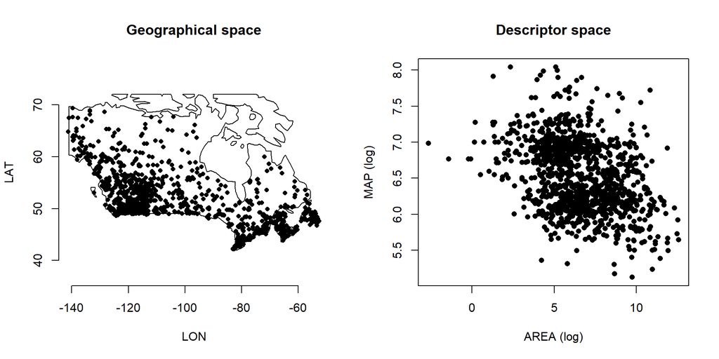

```r
library(floodnetRfa)
library(CSHShydRology)

desc <- log(GAUGEDSITES[,c('area','map')])
coord <- GAUGEDSITES[,c('lon','lat')]

## Generic function to plot the geographical and physical spaces.
myfig <- function(col = 'black', pch = 16, legend.plot = TRUE){

  layout(matrix(c(1,2), 1,2))

  ucol <- sort(unique(col))

  sp::plot(map_ca)
  title(main = 'Geographical space', xlab = 'LON', ylab = 'LAT')
  axis(1)
  axis(2)

  points(coord, pch = pch, col = col, ylim = c(42, 73), cex = .8)

  if(legend.plot)
    legend('top', horiz = TRUE,legend = seq_along(ucol), col = ucol, pch = pch, cex = .6)

  plot(desc, pch = pch, col = col,
           xlab = 'AREA (log)',
           ylab = 'MAP (log)',
           main = 'Descriptor space')

}

myfig(legend.plot = FALSE)
```

To create super regions, we used the Euclidean distance between the transformation of the four coordinates previously mentioned. We take the log transformation on AREA and MAP to obtain descriptors approximately normal, and we employ multidimensional scaling to project the geographical coordinates in a 2D space that tends to preserve the great-circle distance. Moreover, all transformed coordinates are centred and scaled before evaluating the distance.

```r
## Project the coordinate using Multidimensional scaling
ecoord <- -cmdscale(GeoDist(coord),2)
colnames(ecoord) <- c('lon','lat')

xd <- cbind(scale(ecoord), scale(desc))
```

## Results

Hierarchical clustering techniques is a standard method to delineate hydrologically homogenous regions. Here, we consider, more specifically, Ward’s method that gradually agglomerate sites into larger clusters while minimizing the intra-cluster variance at each step. This procedure creates a tree structure that we can cut to form meaningful super regions.

The graphic below illustrates super regions of 6 and 12 clusters, which corresponds to the columns `supreg_hc*` in `gauged_site.csv`. The number of clusters is selected based on the relevance of the extract features according to the author’s judgment. We see that the super regions are relatively compact in both the geographical and the descriptor space.

```r
## Perform the classification

hc <- hclust(dist(xd), method = 'ward.D2')

## Function that reorgnanize the group label by size
OrderGrp <- function(z){
  lon <- tapply(coord[,1], z, median)
  mapid <- match(1:length(lon),order(lon))
  mapid[z]
}

## Identify 4 clusters
hc.grp6 <- OrderGrp(cutree(hc, k = 6))
hc.grp12 <- OrderGrp(cutree(hc, k = 12))

table(hc.grp6)
```

```
## hc.grp6
##   1   2   3   4   5   6
## 115  87 503 137  90 182
```

```r
table(hc.grp12)
```

```
## hc.grp12
##   1   2   3   4   5   6   7   8   9  10  11  12
##  59  87 135  56  59 155 154  28 109  90 117  65
```

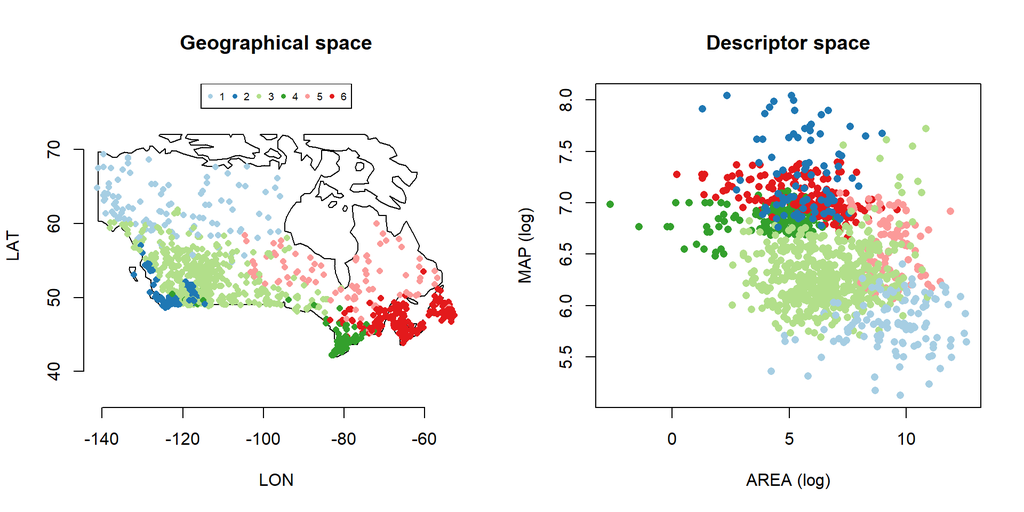

```r
myfig(col = hc.grp6)
```

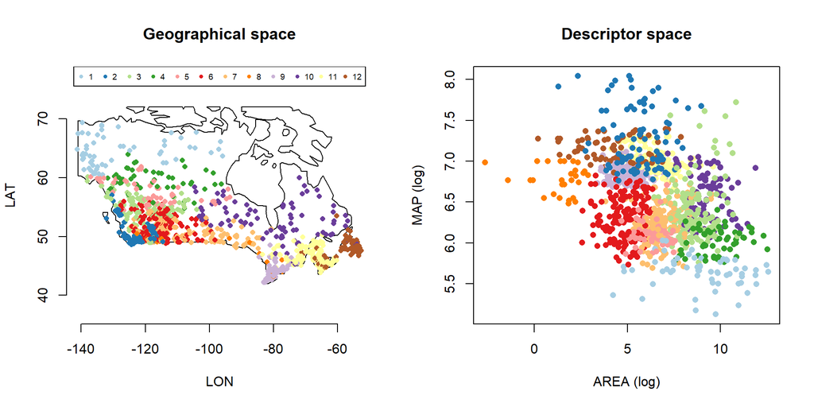

```r
myfig(col = hc.grp12)
```

Another method employed to form super regions is the k-mean clustering technique, where each cluster is defined as the set of the nearest sites to a predetermined set of center points. The algorithm is initialized by selecting random centers and update them until reaching optimized intra-cluster variance. The figures below illustrate super regions of size 6 and 12 using k-mean clustering, which corresponds to the columns `supreg_km*` in `gaugedSites`. In particular, `supreg_km12` identifies super regions roughly representing:

1. North territories - Large area
2. Pacific Coast
3. North of western provinces - Medium Area
4. Fraser and Okanagan Valleys
5. North of Western provinces - Large Area
6. South of Western provinces - Large Area
7. Prairies
8. Southern Ontario
9. Eastern provinces, very small watersheds
10. North of Ontario and Quebec
11. Southern Quebec and Maritimes
12. Newfoundland

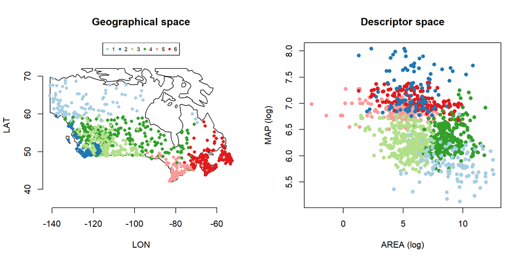

```r
## Identify 4 clusters
set.seed(43)
km.grp6 <- OrderGrp(kmeans(xd, 6, nstart = 100)$cluster)
km.grp12 <- OrderGrp(kmeans(xd, 12, nstart = 100)$cluster)

myfig(col = km.grp6)
```

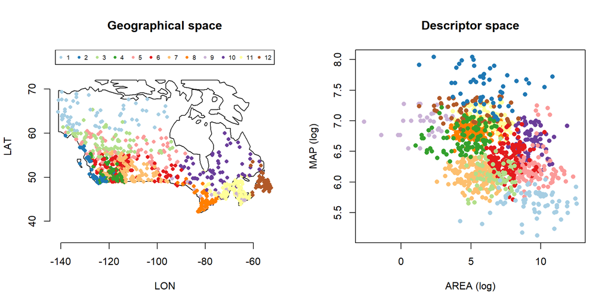

```r
myfig(col = km.grp12)
```

```r
## Final data
supreg <- data.frame(
  supreg_hc6  = hc.grp6,
  supreg_hc12 = hc.grp12,
  supreg_km6  = km.grp6,
  supreg_km12 = km.grp12)
```

## Super regions of new sites

If a site is not in the `gauged_sites` dataset, it can be assigned to one of the existing super regions without performing the complete analysis. A simple way of classifying the new station is to affect the super regions of the nearest sites. The example below follows that strategy and applies it to two new sites created by averaging the attributes of existing sites.

```r
## Extract attributes
xa <- GAUGEDSITES[, c('lon','lat','area','map')]
xa[,3:4] <- log(xa[,3:4])

## Add two new sites as the average of two existing sites
xa <- rbind(colMeans(xa[3:4,]),
            colMeans(xa[201:202,]),
            xa)
rownames(xa) <- c("new1","new2",GAUGEDSITES$station)

## Index of the sites to classify
tid <- 1:2

## Compute the distance between scaled data.
xb <- scale(xa)
h <- as.matrix(dist(xb))[tid,-tid]
cid <- apply(h, 1, which.min)

## Super regions of the sites used to create the new sites
GAUGEDSITES$supreg_hc12[c(3:4,201:202)]
```

```
## [1] 10 10  8  8
```

```r
## Newly classified
GAUGEDSITES$supreg_hc12[cid]
```

```
## [1] 10  8
```

Alternatively, when using the super regions create by the k-means technique, the user can classify the new sites into a super region based on its nearest centers.  
The example below illustrate this approach.

```r
## Apply the previous transformation
xc <- as.data.frame(scale(xa))

## compute the centers
xlst <- split(xc[-tid,], GAUGEDSITES$supreg_km12)
xcenters <- t(sapply(xlst, colMeans))

## compute distance to centers
h <- dist(rbind(xc[tid,], xcenters))
h <- as.matrix(h)[tid,-tid]

GAUGEDSITES$supreg_km12[c(1:2,201:202)]
```

```
## [1] 10 11  8  8
```

```r
apply(h, 1, which.min)
```

```
## new1 new2
##   11    8
```

## References

- Mostofi Zadeh, S., & Burn, D. H. (2019). A Super Region Approach to Improve Pooled Flood Frequency Analysis. Canadian Water Resources Journal / Revue Canadienne Des Ressources Hydriques, 0(0), 1–14. https://doi.org/10.1080/07011784.2018.1548946